# Untitled

# Exploring the strong correlation of active power and apparent power using scatter plot

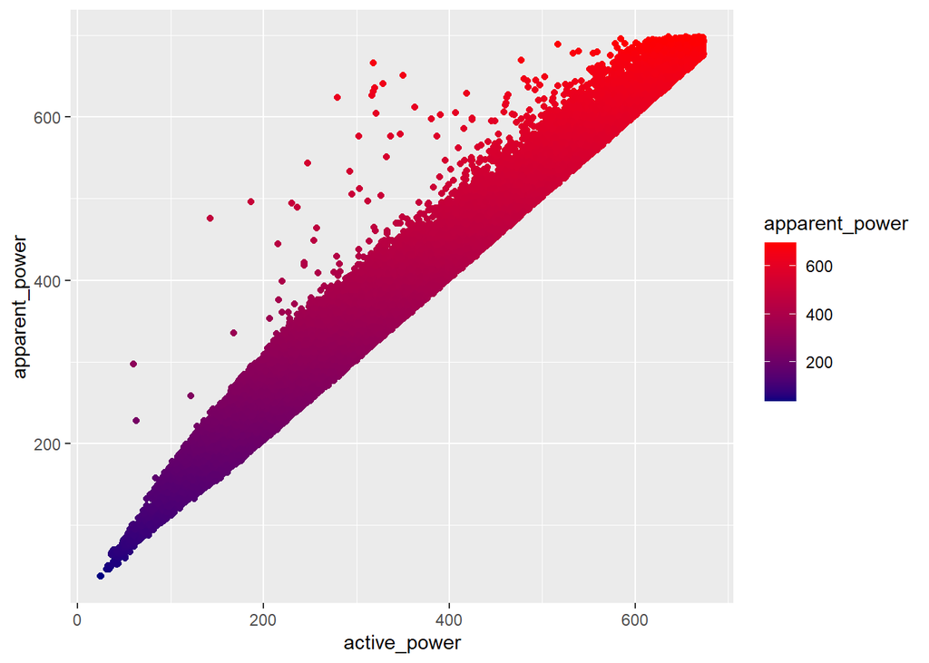

```r
ggplot(energy_capped, aes(x = active_power, y = apparent_power, colour = apparent_power  )) +
  geom_point() + scale_color_gradient(low = "navy", high = "red")
```

# Distribution of ‘main’ categorical variable

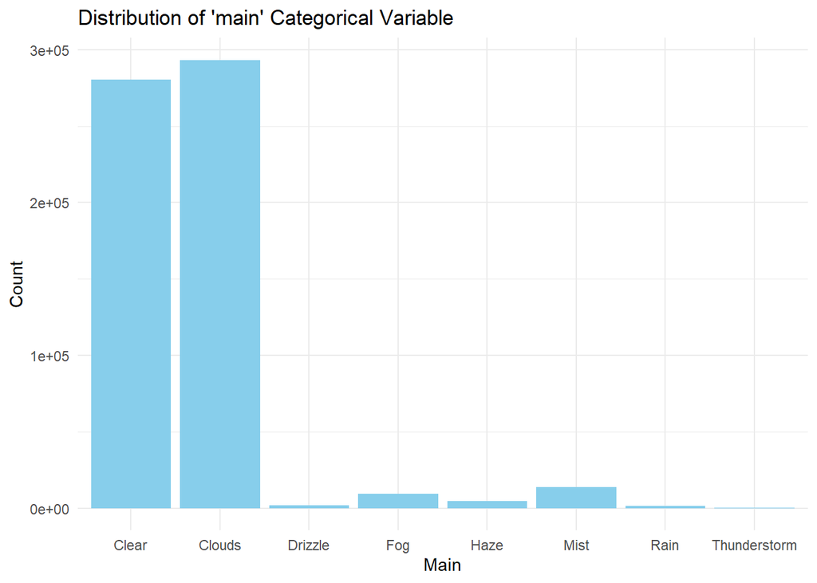

```r
# Bar plot for 'main' categorical variable
ggplot(energy_capped, aes(x = main)) +
  geom_bar(fill = "skyblue") +
  labs(title = "Distribution of 'main' Categorical Variable", x = "Main", y = "Count") +
  theme_minimal()
```

# Distribution of ‘description’ categorical variable

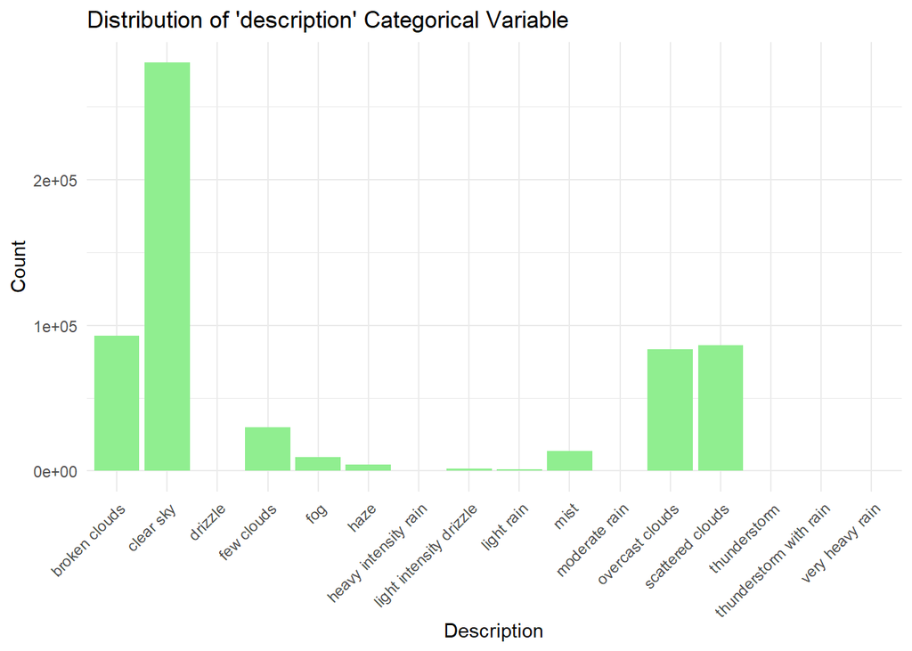

```r
# Bar plot for 'description' categorical variable
ggplot(energy_capped, aes(x = description)) +
  geom_bar(fill = "lightgreen") +
  labs(title = "Distribution of 'description' Categorical Variable", x = "Description", y = "Count") +
  theme_minimal() +
  theme(axis.text.x = element_text(angle = 45, hjust = 1))
```

# Handling Rare Categories

```r
# Define a threshold for rare categories with less than 1% of the total count
threshold <- 0.01 * nrow(energy_capped)

# For 'main' variable
main_counts <- energy_capped %>% count(main)
rare_mains <- main_counts %>% filter(n < threshold) %>% pull(main)

# For 'description' variable
description_counts <- energy_capped %>% count(description)
rare_descriptions <- description_counts %>% filter(n < threshold) %>% pull(description)

# Replace rare categories with 'Other'
energy_category <- energy_capped %>%
  mutate(
    main = ifelse(main %in% rare_mains, 'Other', as.character(main)),
    description = ifelse(description %in% rare_descriptions, 'Other', as.character(description))
  )
```

This aims to identify and consolidate infrequent categories within the main and description variables, likely representing weather conditions or descriptions. Categories occurring in less than 1% of total observations are considered “rare” and combined into a single “Other” category.

# Create interaction terms for categorical variable

```r
# Interaction terms between weather conditions and other numerical features (temp and humidity)
energy_category <- energy_category %>%
  mutate(
    temp_main_interaction = temp * (main == 'Clear'),
    humidity_description_interaction = humidity * (description == 'clear sky')
  )

# View the first few rows of the data set with new features
head(energy_category)
```

```
##              date active_power current voltage reactive_power apparent_power
## 1 11/5/2022 14:05        265.1    2.53   122.2         159.09         309.17
## 2 11/5/2022 14:06        265.1    2.53   122.2         159.09         309.17
## 3 11/5/2022 14:07        265.1    2.53   122.2         159.09         309.17
## 4 11/5/2022 14:08        640.0    5.45   120.7         152.08         657.82
## 5 11/5/2022 14:09        257.6    2.47   122.4         158.26         302.33
## 6 11/5/2022 14:10        257.6    2.47   122.4         158.26         302.33
##   power_factor  main description  temp feels_like temp_min temp_max pressure
## 1       0.8575 Clear   clear sky 24.19      23.68    23.44     27.5     1013
## 2       0.8575 Clear   clear sky 24.19      23.68    23.44     27.5     1013
## 3       0.8575 Clear   clear sky 24.19      23.68    23.44     27.5     1013
## 4       0.9729 Clear   clear sky 24.19      23.68    23.44     27.5     1013
## 5       0.8520 Clear   clear sky 24.19      23.68    23.44     27.5     1013
## 6       0.8520 Clear   clear sky 24.19      23.68    23.44     27.5     1013
##   humidity speed deg temp_t.1 feels_like_t.1            datetime
## 1       39     0   0    29.63          27.97 2022-05-11 14:05:00
## 2       39     0   0    29.63          27.97 2022-05-11 14:06:00
## 3       39     0   0    29.63          27.97 2022-05-11 14:07:00
## 4       39     0   0    29.63          27.97 2022-05-11 14:08:00
## 5       39     0   0    29.63          27.97 2022-05-11 14:09:00
## 6       39     0   0    29.63          27.97 2022-05-11 14:10:00
##   temp_main_interaction humidity_description_interaction
## 1                 24.19                               39
## 2                 24.19                               39
## 3                 24.19                               39
## 4                 24.19                               39
## 5                 24.19                               39
## 6                 24.19                               39
```

Interaction terms in statistical models assess the relationship between numerical features (temperature, humidity) and energy consumption based on weather conditions. In this case, two new columns are created: temp_main_interaction and humidity_description_interaction. The temp_main_interaction column represents the interaction between temperature and the “Clear” weather condition, while the humidity_description_interaction column focuses on the interaction between humidity and the “clear sky” weather description.

# Inspecting missing values

```r
missing_values <- sapply(energy_category, function(x) sum(is.na(x)))
print("Missing values in each column:")
```

```
## [1] "Missing values in each column:"
```

```r
print(missing_values)
```

```
##                             date                     active_power
##                                0                            23398
##                          current                          voltage
##                            25563                              158
##                   reactive_power                   apparent_power
##                             3730                            23813
##                     power_factor                             main
##                                0                                0
##                      description                             temp
##                                0                                0
##                       feels_like                         temp_min
##                                0                                0
##                         temp_max                         pressure
##                                0                                0
##                         humidity                            speed
##                                0                                0
##                              deg                         temp_t.1
##                                0                                0
##                   feels_like_t.1                         datetime
##                                0                           369467
##            temp_main_interaction humidity_description_interaction
##                                0                                0
```

# Visualizing the missing values over time

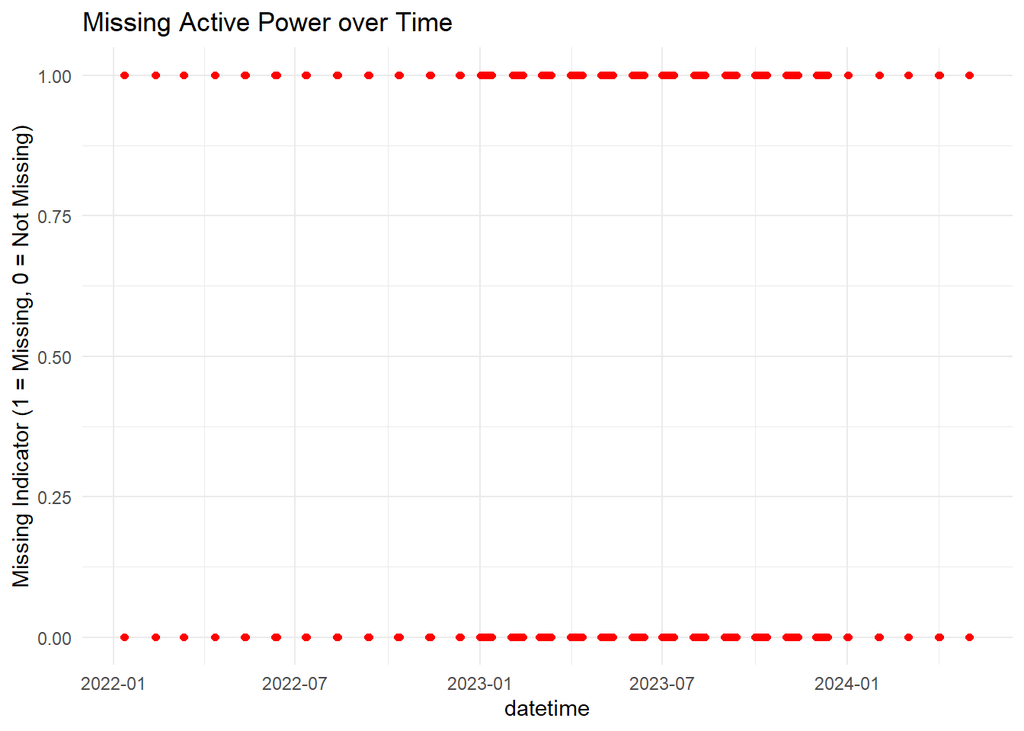

```r
# Step 1: Create missing value indicators
energy_category <- energy_category %>%
  mutate(
    missing_active_power = is.na(active_power),
    missing_current = is.na(current),
    missing_voltage = is.na(voltage),
    missing_reactive_power = is.na(reactive_power),
    missing_apparent_power = is.na(apparent_power)
  )


# Plot to inspect if missing values in active_power are spread over time
ggplot(energy_category, aes(x = datetime)) +
  geom_point(aes(y = as.integer(missing_active_power)), color = "red") +
  labs(title = "Missing Active Power over Time",
       y = "Missing Indicator (1 = Missing, 0 = Not Missing)") +
  theme_minimal()
```

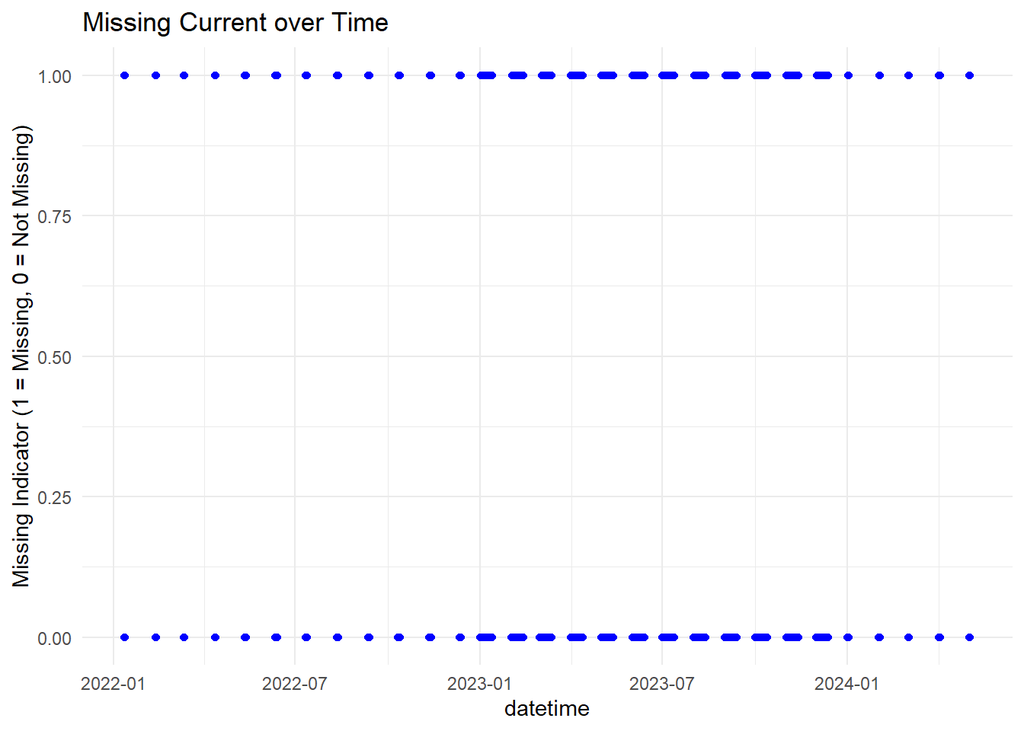

```r
# Plot for current
ggplot(energy_category, aes(x = datetime)) +
  geom_point(aes(y = as.integer(missing_current)), color = "blue") +
  labs(title = "Missing Current over Time",
       y = "Missing Indicator (1 = Missing, 0 = Not Missing)") +
  theme_minimal()
```

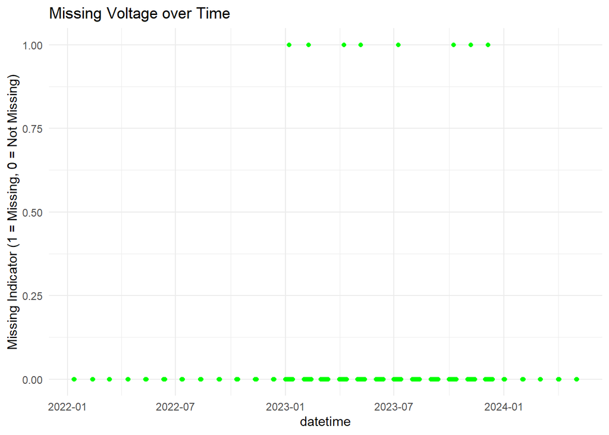

```r
# Plot for voltage
ggplot(energy_category, aes(x = datetime)) +
  geom_point(aes(y = as.integer(missing_voltage)), color = "green") +
  labs(title = "Missing Voltage over Time",
       y = "Missing Indicator (1 = Missing, 0 = Not Missing)") +
  theme_minimal()
```

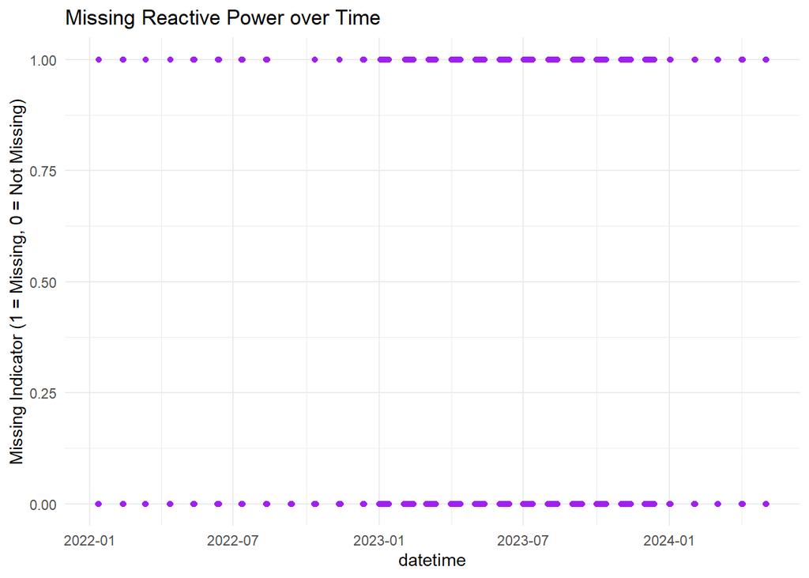

```r
# Plot for reactive_power
ggplot(energy_category, aes(x = datetime)) +
  geom_point(aes(y = as.integer(missing_reactive_power)), color = "purple") +
  labs(title = "Missing Reactive Power over Time",
       y = "Missing Indicator (1 = Missing, 0 = Not Missing)") +
  theme_minimal()
```

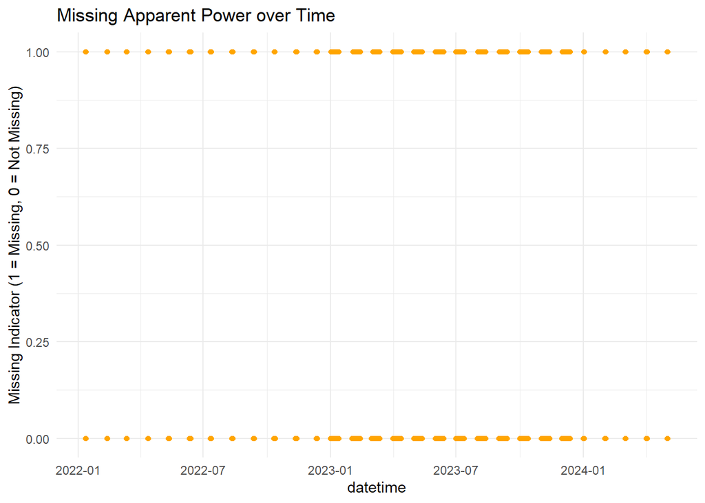

```r
# Plot for apparent_power
ggplot(energy_category, aes(x = datetime)) +
  geom_point(aes(y = as.integer(missing_apparent_power)), color = "orange") +
  labs(title = "Missing Apparent Power over Time",
       y = "Missing Indicator (1 = Missing, 0 = Not Missing)") +
  theme_minimal()
```

```r
# Select columns that have missing values along with datetime
energy_missing <- energy_category %>%
  select(datetime, missing_active_power, missing_current, missing_voltage,
         missing_reactive_power, missing_apparent_power)

# View the first few rows of energy_missing
head(energy_missing)
```

```
##              datetime missing_active_power missing_current missing_voltage
## 1 2022-05-11 14:05:00                FALSE           FALSE           FALSE
## 2 2022-05-11 14:06:00                FALSE           FALSE           FALSE
## 3 2022-05-11 14:07:00                FALSE           FALSE           FALSE
## 4 2022-05-11 14:08:00                FALSE           FALSE           FALSE
## 5 2022-05-11 14:09:00                FALSE           FALSE           FALSE
## 6 2022-05-11 14:10:00                FALSE           FALSE           FALSE
##   missing_reactive_power missing_apparent_power
## 1                  FALSE                  FALSE
## 2                  FALSE                  FALSE
## 3                  FALSE                  FALSE
## 4                  FALSE                  FALSE
## 5                  FALSE                  FALSE
## 6                  FALSE                  FALSE
```

# Addressing Non-Randomly Spread Missing Values Using Forward/Backward Fill

```r
# Forward fill
energy_category <- energy_category %>%
  mutate(
    active_power = zoo::na.locf(active_power, na.rm = FALSE),
    current = zoo::na.locf(current, na.rm = FALSE),
    voltage = zoo::na.locf(voltage, na.rm = FALSE),
    reactive_power = zoo::na.locf(reactive_power, na.rm = FALSE),
    apparent_power = zoo::na.locf(apparent_power, na.rm = FALSE)
  )

# Backward fill
energy_category <- energy_category %>%
  mutate(
    active_power = zoo::na.locf(active_power, fromLast = TRUE, na.rm = FALSE),
    current = zoo::na.locf(current, fromLast = TRUE, na.rm = FALSE),
    voltage = zoo::na.locf(voltage, fromLast = TRUE, na.rm = FALSE),
    reactive_power = zoo::na.locf(reactive_power, fromLast = TRUE, na.rm = FALSE),
    apparent_power = zoo::na.locf(apparent_power, fromLast = TRUE, na.rm = FALSE)
  )



# Forward fill missing datetime values
energy_category <- energy_category %>%
  arrange(datetime) %>%  # Ensure the data is sorted by datetime
  mutate(datetime = na.locf(datetime, na.rm = FALSE))

# Backward fill remaining missing datetime values
energy_category <- energy_category %>%
  mutate(datetime = na.locf(datetime, fromLast = TRUE, na.rm = FALSE))

# Check the first few rows of the dataset to verify imputation
head(energy_category)
```

```
##             date active_power current voltage reactive_power apparent_power
## 1 12/1/2022 0:00        241.9    2.56   124.9         209.09         319.74
## 2 12/1/2022 0:01        241.9    2.56   124.9         209.09         319.74
## 3 12/1/2022 0:02        241.9    2.56   124.9         209.09         319.74
## 4 12/1/2022 0:03        241.9    2.56   124.9         209.09         319.74
## 5 12/1/2022 0:04        241.9    2.56   124.9         209.09         319.74
## 6 12/1/2022 0:05        241.9    2.56   124.9         209.09         319.74
##   power_factor   main      description  temp feels_like temp_min temp_max
## 1       0.7566 Clouds scattered clouds 10.36       9.75    10.36    13.63
## 2       0.7566 Clouds scattered clouds 10.36       9.75    10.36    13.63
## 3       0.7566 Clouds scattered clouds 10.36       9.75    10.36    13.63
## 4       0.7566 Clouds scattered clouds 10.36       9.75    10.36    13.63
## 5       0.7566 Clouds scattered clouds 10.36       9.75    10.36    13.63
## 6       0.7566 Clouds scattered clouds 10.36       9.75    10.36    13.63
##   pressure humidity speed deg temp_t.1 feels_like_t.1            datetime
```

[output cut: 20 more lines]

# Verify imputation for power variables

```r
missing_values <- sapply(energy_category, function(x) sum(is.na(x)))
print("Verify imputation for missing values in each column:")
```

```
## [1] "Verify imputation for missing values in each column:"
```

```r
print(missing_values)
```

```
##                             date                     active_power
##                                0                                0
##                          current                          voltage
##                                0                                0
##                   reactive_power                   apparent_power
##                                0                                0
##                     power_factor                             main
##                                0                                0
##                      description                             temp
##                                0                                0
##                       feels_like                         temp_min
##                                0                                0
##                         temp_max                         pressure
##                                0                                0
##                         humidity                            speed
##                                0                                0
##                              deg                         temp_t.1
##                                0                                0
##                   feels_like_t.1                         datetime
##                                0                                0
##            temp_main_interaction humidity_description_interaction
##                                0                                0
##             missing_active_power                  missing_current
##                                0                                0
##                  missing_voltage           missing_reactive_power
##                                0                                0
##           missing_apparent_power
##                                0
```

# Converting the target variable (active_power) to categorical

```r
# Define bins for active_power
bins <- quantile(energy_category$active_power, probs = seq(0, 1, 0.25))
labels <- c("Low", "Medium-Low", "Medium-High", "High")

# Convert active_power to categorical
energy_category <- energy_category %>%
  mutate(active_power_class = cut(active_power, breaks = bins, labels = labels, include.lowest = TRUE))

# View the distribution of the new categorical variable
table(energy_category$active_power_class)
```

```
##
##         Low  Medium-Low Medium-High        High
##      151551      151185      151215      151307
```

```r
bin_ranges <- data.frame(
  Label = labels,
  Lower_Bound = bins[-length(bins)],
  Upper_Bound = bins[-1]
)

# View the bin ranges
print(bin_ranges)
```

```
##           Label Lower_Bound Upper_Bound
## 0%          Low        24.4       159.5
## 25%  Medium-Low       159.5       248.8
## 50% Medium-High       248.8       359.4
## 75%        High       359.4       673.8
```

# Encoding Categorical Variables

```r
# Create dummy variables for 'main' and 'description' columns
dummies <- dummyVars(~ main + description, data = energy_category)

# Transform the data set
energy_transformed <- predict(dummies, newdata = energy_category)

# Convert to data frame
energy_transformed <- as.data.frame(energy_transformed)

# Remove the original 'main' and 'description' columns
energy_final <- cbind(select(energy_category, -main, -description), energy_transformed)

head(energy_final)
```

```
##             date active_power current voltage reactive_power apparent_power
## 1 12/1/2022 0:00        241.9    2.56   124.9         209.09         319.74
## 2 12/1/2022 0:01        241.9    2.56   124.9         209.09         319.74
## 3 12/1/2022 0:02        241.9    2.56   124.9         209.09         319.74
## 4 12/1/2022 0:03        241.9    2.56   124.9         209.09         319.74
## 5 12/1/2022 0:04        241.9    2.56   124.9         209.09         319.74
## 6 12/1/2022 0:05        241.9    2.56   124.9         209.09         319.74
##   power_factor  temp feels_like temp_min temp_max pressure humidity speed deg
## 1       0.7566 10.36       9.75    10.36    13.63     1020       88  2.08  85
## 2       0.7566 10.36       9.75    10.36    13.63     1020       88  2.08  85
## 3       0.7566 10.36       9.75    10.36    13.63     1020       88  2.08  85
## 4       0.7566 10.36       9.75    10.36    13.63     1020       88  2.08  85
## 5       0.7566 10.36       9.75    10.36    13.63     1020       88  2.08  85
## 6       0.7566 10.36       9.75    10.36    13.63     1020       88  2.08  85
##   temp_t.1 feels_like_t.1            datetime temp_main_interaction
```

[output cut: 48 more lines]

# Features Selection

```r
set.seed(123)

# Feature selection with a  one-variable predictor
model1 = lm(active_power ~ current, data = energy_final)

summary(model1)
```

```
##
## Call:
## lm(formula = active_power ~ current, data = energy_final)
##
## Residuals:
##     Min      1Q  Median      3Q     Max
## -602.15  -17.72    3.15   17.95  548.76
##
## Coefficients:
##              Estimate Std. Error t value Pr(>|t|)
## (Intercept) -27.05018    0.08500  -318.2   <2e-16 ***
## current     121.64258    0.03129  3887.2   <2e-16 ***
## ---
## Signif. codes:  0 '***' 0.001 '**' 0.01 '*' 0.05 '.' 0.1 ' ' 1
##
## Residual standard error: 28.86 on 605256 degrees of freedom
## Multiple R-squared:  0.9615, Adjusted R-squared:  0.9615
## F-statistic: 1.511e+07 on 1 and 605256 DF,  p-value: < 2.2e-16
```

```r
# Feature selection with a  two-variable predictor
model2 = lm(active_power ~ current+apparent_power, data = energy_final)

summary(model2)
```

```
##
## Call:
## lm(formula = active_power ~ current + apparent_power, data = energy_final)
##
## Residuals:
##     Min      1Q  Median      3Q     Max
## -585.09  -14.42    4.18   19.29  473.70
##
## Coefficients:
##                  Estimate Std. Error t value Pr(>|t|)
## (Intercept)    -31.842841   0.079064  -402.7   <2e-16 ***
## current         39.892021   0.240692   165.7   <2e-16 ***
## apparent_power   0.669535   0.001957   342.1   <2e-16 ***
## ---
## Signif. codes:  0 '***' 0.001 '**' 0.01 '*' 0.05 '.' 0.1 ' ' 1
##
## Residual standard error: 26.42 on 605255 degrees of freedom
## Multiple R-squared:  0.9677, Adjusted R-squared:  0.9677
## F-statistic: 9.074e+06 on 2 and 605255 DF,  p-value: < 2.2e-16
```

```r
# Feature selection with a  three-variable predictor
model3 = lm(active_power ~ current+apparent_power+power_factor+reactive_power, data = energy_final)

summary(model3)
```

```
##
## Call:
## lm(formula = active_power ~ current + apparent_power + power_factor +
##     reactive_power, data = energy_final)
##
## Residuals:
##     Min      1Q  Median      3Q     Max
## -630.63   -4.07   -0.79    3.18  519.23
##
## Coefficients:
##                  Estimate Std. Error t value Pr(>|t|)
## (Intercept)    -9.078e+01  2.367e-01  -383.6   <2e-16 ***
## current         3.424e+01  1.369e-01   250.2   <2e-16 ***
## apparent_power  7.368e-01  1.125e-03   655.0   <2e-16 ***
## power_factor    1.050e+02  2.906e-01   361.4   <2e-16 ***
## reactive_power -2.891e-01  5.743e-04  -503.5   <2e-16 ***
## ---
## Signif. codes:  0 '***' 0.001 '**' 0.01 '*' 0.05 '.' 0.1 ' ' 1
##
## Residual standard error: 14.98 on 605253 degrees of freedom
## Multiple R-squared:  0.9896, Adjusted R-squared:  0.9896
## F-statistic: 1.444e+07 on 4 and 605253 DF,  p-value: < 2.2e-16
```

# Extract datetime components

```r
#energy_final <- energy_final %>%
  #mutate(
    #hour = as.numeric(format(datetime, "%H")),
    #day = as.numeric(format(datetime, "%d")),
    #month = as.numeric(format(datetime, "%m")),
    #day_of_week = as.numeric(format(datetime, "%u"))
 #)
```

# Creating new sample data (5% of original dataset)

```r
# Calculate new sample size (10% of the dataset)
New_Sample <- floor(0.05 * nrow(energy_final))

# Calculate the sample size per class
New_Sample_per_class <- New_Sample / length(unique(energy_final$active_power_class))

# To Create a stratified sample ensuring equal representation of the target variable

set.seed(123) # for reproducibility
Energy_New <- energy_final %>%
  group_by(active_power_class) %>%
  sample_n(ceiling(New_Sample_per_class))


# Save the new sampled data to a new data frame
Energy_New_df <- as.data.frame(Energy_New)

# View the first few rows of the sampled data
head(Energy_New_df)
```

```
##              date active_power current voltage reactive_power apparent_power
## 1 11/25/2023 8:48        141.4    1.65   133.6         169.11         220.44
## 2 10/25/2023 9:59        128.0    1.12   129.7          68.68         145.26
## 3  4/29/2023 5:50        135.5    1.65   124.7         154.83         205.75
## 4 10/27/2023 6:23        117.6    1.03   133.6          71.46         137.61
## 5  1/11/2023 6:07        151.9    1.88   125.3         180.04         235.56
## 6 12/17/2022 0:41        135.6    1.48   125.2         126.29         185.30
##   power_factor  temp feels_like temp_min temp_max pressure humidity speed deg
## 1       0.6414 14.63      13.72     6.44    17.59     1016       60  0.00   0
## 2       0.8812 21.84      21.72    19.60    23.14     1014       63  0.00   0
## 3       0.6586 10.92       9.84    10.30    11.39     1012       68  0.45  58
## 4       0.8546 19.83      19.59    17.50    20.63     1012       66  0.60 126
## 5       0.6448 12.59      10.84    12.59    14.44     1016       36  4.12 180
## 6       0.7318  9.25       8.38     8.63     9.25     1014       80  1.93  49
##   temp_t.1 feels_like_t.1            datetime temp_main_interaction
```

[output cut: 48 more lines]

# Feature Engineering

```r
# Lag Features
energy_final2 <- Energy_New_df %>%
  arrange(datetime) %>% # Ensure data is sorted by time
  mutate(
    lag_active_power_1 = lag(active_power, n = 1),   # 1-minute lag
    lag_active_power_60 = lag(active_power, n = 60),  # 1-hour lag
    lag_active_power_1440 = lag(active_power, n = 1440), # 1-day lag
    lag_current_1 = lag(current, n = 1),
    lag_temp_1 = lag(temp, n = 1),
    lag_humidity_1 = lag(humidity, n = 1)
  )

#  Time Components
energy_final2 <- energy_final2 %>%
  mutate(
    hour_of_day = as.numeric(format(datetime, "%H")),
    day_of_week = as.numeric(format(datetime, "%u")),
    month_of_year = as.numeric(format(datetime, "%m")),
    is_weekend = ifelse(day_of_week %in% c(6, 7), 1, 0) # 1 for weekend, 0 for weekday
  )

# Rolling Statistics
energy_final2 <- energy_final2 %>%
  mutate(
    rolling_mean_active_power_30 = rollmean(active_power, k = 30, fill = NA, align = "right"), # 30-min moving average
    rolling_max_active_power_60 = rollapply(active_power, width = 60, FUN = max, fill = NA, align = "right"), # 1-hour max
    rolling_mean_temp_7 = rollmean(temp, k = 7*24*60, fill = NA, align = "right"), # 7-day moving average
    rolling_std_temp_7 = rollapply(temp, width = 7*24*60, FUN = sd, fill = NA, align = "right")
  )

# Weather-Related Interactions
energy_final2 <- energy_final2 %>%
  mutate(
    temp_x_hour_of_day = temp * hour_of_day,
    humidity_x_month_of_year = humidity * month_of_year
  )

head(energy_final2)
```

```
##             date active_power current voltage reactive_power apparent_power
## 1 12/1/2022 0:17        241.9    2.56   124.9         209.09         319.74
## 2 12/1/2022 0:59         74.8    0.83   126.4          73.56         104.91
## 3 12/1/2022 1:00         74.8    0.83   126.4          73.56         104.91
## 4 12/1/2022 1:07         74.8    0.83   126.4          73.56         104.91
## 5 12/1/2022 1:49        250.0    2.27   125.1         134.70         283.98
## 6 12/1/2022 2:07        270.8    2.52   125.3         162.39         315.76
##   power_factor  temp feels_like temp_min temp_max pressure humidity speed deg
## 1       0.7566 10.36       9.75    10.36    10.36     1020       88  2.08  85
## 2       0.7130  9.81       9.21     9.81     9.81     1019       88  1.73 108
## 3       0.7130  9.81       9.21     9.81     9.81     1019       88  1.73 108
## 4       0.7130  9.81       9.21     9.81     9.81     1019       88  1.73 108
## 5       0.8803  8.70       8.02     8.70    12.52     1020       79  1.64 114
## 6       0.8576  8.70       8.02     8.70    11.96     1019       71  1.64 114
##   temp_t.1 feels_like_t.1            datetime temp_main_interaction
```

[output cut: 76 more lines]

# Verify that there are no missing values left

```r
missing_values_after <- sapply(energy_final2, function(x) sum(is.na(x)))
print("Missing values after imputation:")
```

```
## [1] "Missing values after imputation:"
```

```r
print(missing_values_after)
```

```
##                             date                     active_power
##                                0                                0
##                          current                          voltage
##                                0                                0
##                   reactive_power                   apparent_power
##                                0                                0
##                     power_factor                             temp
##                                0                                0
##                       feels_like                         temp_min
##                                0                                0
##                         temp_max                         pressure
##                                0                                0
##                         humidity                            speed
##                                0                                0
##                              deg                         temp_t.1
##                                0                                0
##                   feels_like_t.1                         datetime
##                                0                                0
##            temp_main_interaction humidity_description_interaction
##                                0                                0
##             missing_active_power                  missing_current
##                                0                                0
##                  missing_voltage           missing_reactive_power
##                                0                                0
##           missing_apparent_power               active_power_class
##                                0                                0
##                        mainClear                       mainClouds
##                                0                                0
##                          mainFog                         mainMist
##                                0                                0
##                        mainOther         descriptionbroken clouds
##                                0                                0
##             descriptionclear sky            descriptionfew clouds
##                                0                                0
##                   descriptionfog                  descriptionmist
##                                0                                0
##                 descriptionOther       descriptionovercast clouds
##                                0                                0
##      descriptionscattered clouds               lag_active_power_1
##                                0                                1
##              lag_active_power_60            lag_active_power_1440
##                               60                             1440
##                    lag_current_1                       lag_temp_1
##                                1                                1
##                   lag_humidity_1                      hour_of_day
##                                1                                0
##                      day_of_week                    month_of_year
##                                0                                0
##                       is_weekend     rolling_mean_active_power_30
##                                0                               29
##      rolling_max_active_power_60              rolling_mean_temp_7
##                               59                            10079
##               rolling_std_temp_7               temp_x_hour_of_day
##                            10079                                0
##         humidity_x_month_of_year
##                                0
```

However, the lag features and rolling statistic have introduce some missing values. Therefore, this will be omitted from the dataframe.

# Omit missing values

```r
energy_final2 <- na.omit(energy_final2)
```

# Remove redundant columns

```r
energy_final2$date <- NULL
energy_final2$datetime <- NULL
energy_final2$active_power <- NULL
```

```r
Energy_New_df <- energy_final2
```

Due to lack of high computational processing power requirements, I decided to train work with five percent of the dataset.

# Check the distribution of target variable of the new sampled data

```r
table(Energy_New_df$active_power_class)
```

```
##
##         Low  Medium-Low Medium-High        High
##        5260        4882        4882        5161
```

# Feature Selection Using the Recursive Feature Elimination with Cross-Validation

```r
# Check the unique classes in the response variable
unique_classes <- unique(Energy_New_df$active_power_class)
print(unique_classes)
```

```
## [1] Low         Medium-Low  Medium-High High
## Levels: Low Medium-Low Medium-High High
```

```r
# Ensure there are at least two classes
if (length(unique_classes) < 2) {
  stop("The response variable must have at least two unique classes.")
}

# Define the predictor and response variables
predictors <- Energy_New_df %>% select(-active_power_class)
response <- Energy_New_df$active_power_class

# Define the control using rfeControl
control <- rfeControl(functions = rfFuncs,
                      method = "cv",
                      number = 5)

# Run RFE
set.seed(123)
rfe_results <- rfe(predictors, response,
                   sizes = c(1:56),
                   rfeControl = control)

# Print the results
print(rfe_results)
```

```
##
## Recursive feature selection
##
## Outer resampling method: Cross-Validated (5 fold)
##
## Resampling performance over subset size:
##
##  Variables Accuracy  Kappa AccuracySD   KappaSD Selected
##          1   0.9637 0.9516  0.0048104 0.0064153
##          2   0.9621 0.9494  0.0034971 0.0046656
##          3   0.9693 0.9590  0.0118830 0.0158513
##          4   0.9910 0.9880  0.0022804 0.0030416
##          5   0.9919 0.9892  0.0024801 0.0033080
##          6   0.9914 0.9886  0.0023545 0.0031406
##          7   0.9965 0.9954  0.0007838 0.0010454
```

[output cut: 47 more lines]

```r
# List the chosen features
chosen_features <- predictors(rfe_results)
print(chosen_features)
```

```
## [1] "lag_active_power_1"           "rolling_max_active_power_60"
## [3] "rolling_mean_active_power_30" "apparent_power"
## [5] "current"                      "rolling_mean_temp_7"
## [7] "power_factor"                 "lag_active_power_60"
## [9] "rolling_std_temp_7"
```

```r
# Create a new dataset with the selected features
Energy_New_df_selected <- Energy_New_df %>% select(all_of(chosen_features), active_power_class)

# Check the structure of the new dataset
str(Energy_New_df_selected)
```

```
## 'data.frame':    20185 obs. of  10 variables:
##  $ lag_active_power_1          : num  277.1 97.3 164.7 164.7 164.7 ...
##  $ rolling_max_active_power_60 : num  490 490 490 490 490 ...
##  $ rolling_mean_active_power_30: num  220 220 220 218 218 ...
##  $ apparent_power              : num  136 238 238 238 240 ...
##  $ current                     : num  1.1 1.92 1.92 1.92 1.94 2.06 2.06 2.06 1.12 1.12 ...
##  $ rolling_mean_temp_7         : num  20.1 20.1 20.1 20.1 20.1 ...
##  $ power_factor                : num  0.716 0.692 0.692 0.692 0.931 ...
##  $ lag_active_power_60         : num  228 228 223 169 169 ...
##  $ rolling_std_temp_7          : num  6.02 6.01 6.01 6.01 6.01 ...
##  $ active_power_class          : Factor w/ 4 levels "Low","Medium-Low",..: 1 2 2 2 2 2 2 2 1 1 ...
##  - attr(*, "na.action")= 'omit' Named int [1:10079] 1 2 3 4 5 6 7 8 9 10 ...
##   ..- attr(*, "names")= chr [1:10079] "1" "2" "3" "4" ...
```

# Data Splitting (Train = 80%, Test = 20%)

```r
set.seed(123)

# Create data partition to ensure the target is evenly distributed across the training and testing set
Train_partition <- createDataPartition(Energy_New_df_selected$active_power_class, p = 0.8, list = FALSE)

# Create the training and testing datasets
Train_data <- Energy_New_df_selected[Train_partition, ]
Test_data <- Energy_New_df_selected[-Train_partition, ]

# Create control for all models
ctrl = trainControl(method = 'cv', number = 5)
```

# Distribution of the target variable in the train and test set

```r
# Distribution of the target variable in the training set
cat("Training Set Distribution:\n")
```

```
## Training Set Distribution:
```

```r
print(table(Train_data$active_power_class))
```

```
##
##         Low  Medium-Low Medium-High        High
##        4208        3906        3906        4129
```

```r
# Distribution of the target variable in the testing set
cat("\nTesting Set Distribution:\n")
```

```
##
## Testing Set Distribution:
```

```r
print(table(Test_data$active_power_class))
```

```
##
##         Low  Medium-Low Medium-High        High
##        1052         976         976        1032
```

# Model for Random Forest Using Default Settings

```r
set.seed(123)

# Train the RF model using default settings
rf_model <- randomForest(active_power_class ~ .,
                         data = Train_data)

# Print the model details
print(rf_model)
```

```
##
## Call:
##  randomForest(formula = active_power_class ~ ., data = Train_data)
##                Type of random forest: classification
##                      Number of trees: 500
## No. of variables tried at each split: 3
##
##         OOB estimate of  error rate: 0.37%
## Confusion matrix:
##              Low Medium-Low Medium-High High class.error
## Low         4196         12           0    0 0.002851711
## Medium-Low     5       3892           9    0 0.003584229
## Medium-High    0          9        3885   12 0.005376344
## High           0          0          12 4117 0.002906273
```

The Random Forest classifier forecasts the active_power_class by employing 500 decision trees, each utilizing three randomly chosen variables. It demonstrates a minimal out-of-bag error rate of 0.37% and exhibits robust performance across all categorical classes. The model showcases elevated accuracy, a limited number of misclassifications, and performance tailored to specific classes, thereby underscoring its efficacy in predicting active_power_class based on the training dataset.

# Evaluate the model on Test set

```r
# Predict on the testing set
rf_pred <- predict(rf_model, newdata = Test_data)
```

# Confusion matrix to evaluate performance

```r
conf_matrix <- confusionMatrix(rf_pred, Test_data$active_power_class)
conf_matrix
```

```
## Confusion Matrix and Statistics
##
##              Reference
## Prediction     Low Medium-Low Medium-High High
##   Low         1051          3           0    0
##   Medium-Low     1        970           4    0
##   Medium-High    0          3         971    2
##   High           0          0           1 1030
##
## Overall Statistics
##
##                Accuracy : 0.9965
##                  95% CI : (0.9942, 0.9981)
##     No Information Rate : 0.2607
##     P-Value [Acc > NIR] : < 2.2e-16
##
##                   Kappa : 0.9954
##
##  Mcnemar's Test P-Value : NA
##
## Statistics by Class:
##
##                      Class: Low Class: Medium-Low Class: Medium-High
## Sensitivity              0.9990            0.9939             0.9949
## Specificity              0.9990            0.9984             0.9984
## Pos Pred Value           0.9972            0.9949             0.9949
## Neg Pred Value           0.9997            0.9980             0.9984
## Prevalence               0.2607            0.2418             0.2418
## Detection Rate           0.2604            0.2403             0.2406
## Detection Prevalence     0.2611            0.2416             0.2418
## Balanced Accuracy        0.9990            0.9961             0.9966
##                      Class: High
## Sensitivity               0.9981
## Specificity               0.9997
## Pos Pred Value            0.9990
## Neg Pred Value            0.9993
## Prevalence                0.2557
## Detection Rate            0.2552
## Detection Prevalence      0.2555
## Balanced Accuracy         0.9989
```

The model exhibits an exceptional level of accuracy, achieving a commendable rate of 0.9965, thereby correctly predicting the classes for 99.65% of instances. This indicates a solid class-specific performance, noted for its heightened sensitivity, specificity, positive predictive value, and negative predictive value. The distribution of each class is equitably balanced, with proportions ranging from 0.2418 to 0.2607. There exists a minimal occurrence of misclassifications and an absence of significant bias, thereby underscoring its proficiency in the classification of data.

# PostResampling

```r
postResample(rf_pred, Test_data$active_power_class)
```

```
##  Accuracy     Kappa
## 0.9965312 0.9953732
```

# Plot model

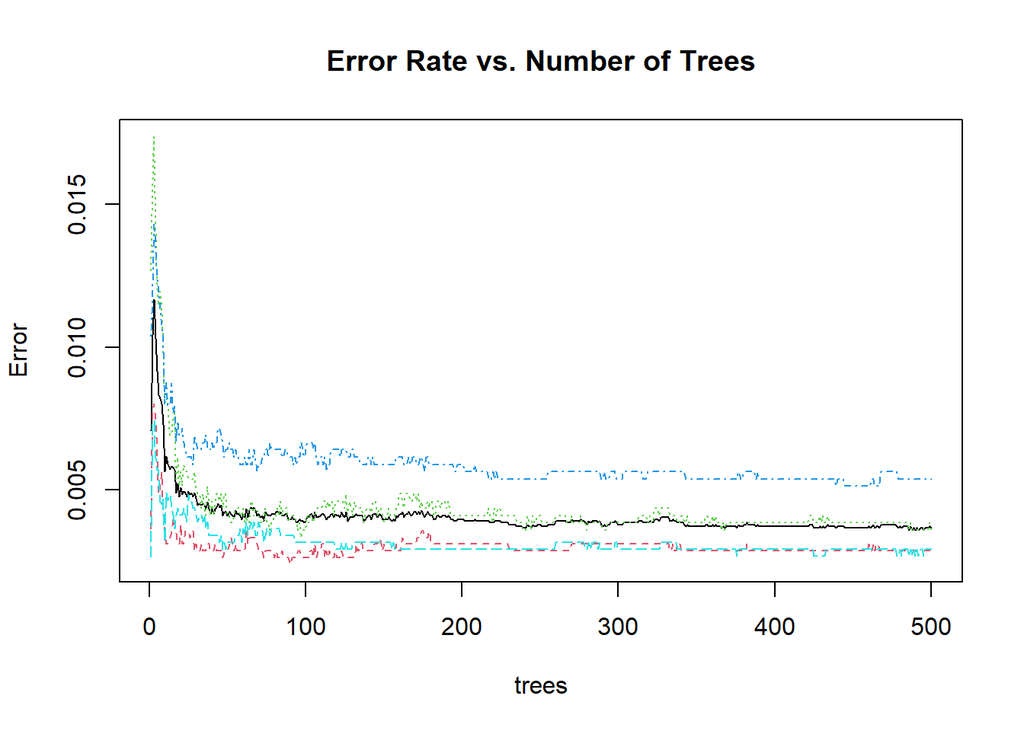

```r
# Plot the error rate across trees
plot(rf_model, main="Error Rate vs. Number of Trees")
```

# Plot feature importance

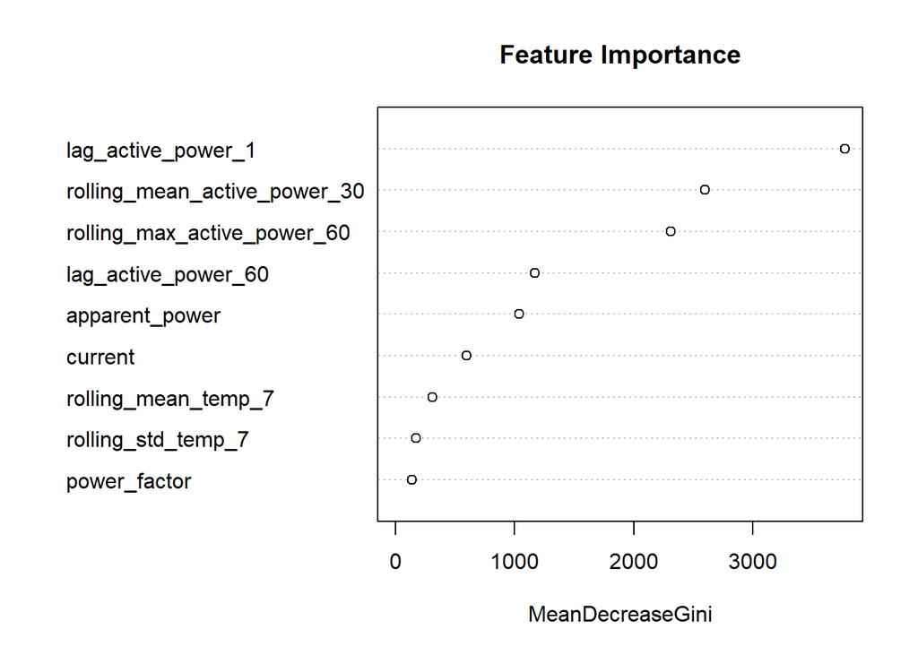

```r
importance <- importance(rf_model)
varImpPlot(rf_model, main="Feature Importance")
```

# Precision, Recall and F1 Score

```r
# Extract Precision, Recall, and F1 Score
precision <- conf_matrix$byClass[, "Pos Pred Value"]
recall <- conf_matrix$byClass[, "Sensitivity"]
support <- table(Test_data$active_power_class)

f1_score <- 2 * ((precision * recall) / (precision + recall))


# Combine into a data frame
metrics_rf <- data.frame(
  Class = rownames(conf_matrix$byClass),
  Precision = precision,
  Recall = recall,
  F1_Score = f1_score
)

# Print the metrics
print(metrics_rf)
```

```
##                                 Class Precision    Recall  F1_Score
## Class: Low                 Class: Low 0.9971537 0.9990494 0.9981007
## Class: Medium-Low   Class: Medium-Low 0.9948718 0.9938525 0.9943619
## Class: Medium-High Class: Medium-High 0.9948770 0.9948770 0.9948770
## Class: High               Class: High 0.9990301 0.9980620 0.9985458
```

# Area under curve for Random forest model with defalt

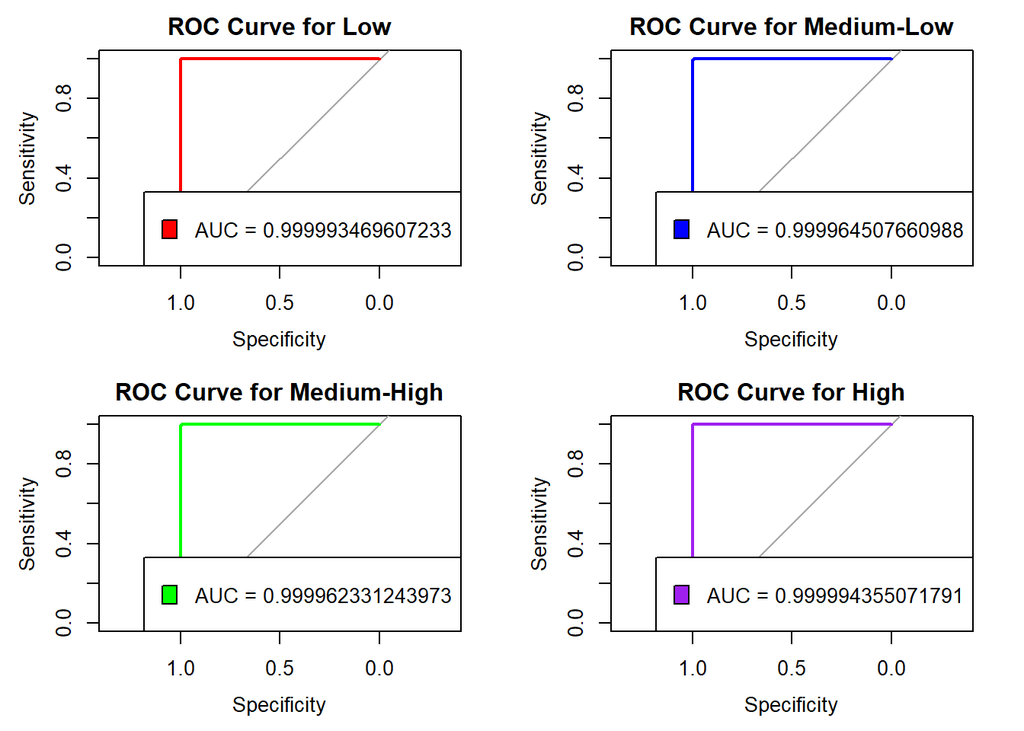

```r
# Predict probabilities on the testing set with the tuned model
rf_prob <- predict(rf_model, newdata = Test_data, type = "prob")

# Setup plot area
par(mfrow = c(2, 2))  # Adjust grid layout depending on the number of classes, e.g., 4 classes
colors <- c("red", "blue", "green", "purple")  # Define colors for each ROC curve

# Create a list to store ROC curves
roc_curves <- list()

for (i in 1:ncol(rf_prob)) {
    # Convert multi-class to binary class responses for the current class
    binary_response <- factor(ifelse(Test_data$active_power_class == colnames(rf_prob)[i], "pos", "neg"), levels = c("neg", "pos"))

    # Check if there are both positive and negative cases
    if (sum(binary_response == "pos") > 0 && sum(binary_response == "neg") > 0) {
        # Compute ROC curve using the pROC package
        roc_curves[[i]] <- roc(binary_response, rf_prob[, i])

        # Plot the ROC curve
        plot(roc_curves[[i]], main = paste("ROC Curve for", colnames(rf_prob)[i]), col = colors[i])

        # Add a legend displaying the exact AUC without rounding
        legend("bottomright", legend = c(paste("AUC =", auc(roc_curves[[i]]))), fill = colors[i])
    } else {
        message(paste("Skipping ROC curve for", colnames(rf_prob)[i], ": No positive cases or no negative cases."))
    }
}
```

```r
Energy_New_df_selected2 <- Energy_New_df_selected

set.seed(123)

# Create data partition
Train_partition2 <- createDataPartition(Energy_New_df_selected2$active_power_class, p = 0.8, list = FALSE)

# Train and Test Split
Train_data2 <- Energy_New_df_selected2[Train_partition2, ]
Test_data2 <- Energy_New_df_selected2[-Train_partition2, ]
```

# Random Forest Model Using Hyperparameters

```r
set.seed(123)


# Define the hyperparameter
tunegrid <- expand.grid(mtry = c(2, 4, 6)         # Number of variables randomly sampled at each split
)

# Define the control parameters for training
control <- trainControl(
  method = "cv",              # Use cross-validation
  number = 5,                 # 5-fold cross-validation
  search = "grid"             # Perform grid search over the hyperparameter grid
)

# Train the Random Forest model
set.seed(123)
rf_model_tune <- train(
  active_power_class ~ .,
  data = Train_data2,
  method = "rf",
  trControl = control,
  tuneGrid = tunegrid,
  ntree = 500
)

# Print the model
print(rf_model_tune)
```

```
## Random Forest
##
## 16149 samples
##     9 predictor
##     4 classes: 'Low', 'Medium-Low', 'Medium-High', 'High'
##
## No pre-processing
## Resampling: Cross-Validated (5 fold)
## Summary of sample sizes: 12919, 12919, 12918, 12920, 12920
## Resampling results across tuning parameters:
##
##   mtry  Accuracy   Kappa
##   2     0.9954798  0.9939709
##   4     0.9959751  0.9946316
##   6     0.9948607  0.9931451
##
## Accuracy was used to select the optimal model using the largest value.
## The final value used for the model was mtry = 4.
```

# Evaluate RF tune model

```r
# Predict on the testing set
rf_pred_tune <- predict(rf_model_tune, newdata = Test_data2)

# Confusion matrix to evaluate performance
conf_matrix_rftune <- confusionMatrix(rf_pred_tune, Test_data2$active_power_class)
conf_matrix_rftune
```

```
## Confusion Matrix and Statistics
##
##              Reference
## Prediction     Low Medium-Low Medium-High High
##   Low         1051          3           0    0
##   Medium-Low     1        970           4    0
##   Medium-High    0          3         971    1
##   High           0          0           1 1031
##
## Overall Statistics
##
##                Accuracy : 0.9968
##                  95% CI : (0.9945, 0.9983)
##     No Information Rate : 0.2607
##     P-Value [Acc > NIR] : < 2.2e-16
##
##                   Kappa : 0.9957
##
##  Mcnemar's Test P-Value : NA
##
## Statistics by Class:
##
##                      Class: Low Class: Medium-Low Class: Medium-High
## Sensitivity              0.9990            0.9939             0.9949
## Specificity              0.9990            0.9984             0.9987
## Pos Pred Value           0.9972            0.9949             0.9959
## Neg Pred Value           0.9997            0.9980             0.9984
## Prevalence               0.2607            0.2418             0.2418
## Detection Rate           0.2604            0.2403             0.2406
## Detection Prevalence     0.2611            0.2416             0.2416
## Balanced Accuracy        0.9990            0.9961             0.9968
##                      Class: High
## Sensitivity               0.9990
## Specificity               0.9997
## Pos Pred Value            0.9990
## Neg Pred Value            0.9997
## Prevalence                0.2557
## Detection Rate            0.2555
## Detection Prevalence      0.2557
## Balanced Accuracy         0.9993
```

# RF Accuracy with tune

```r
postResample(rf_pred_tune, Test_data2$active_power_class)
```

```
##  Accuracy     Kappa
## 0.9967790 0.9957037
```

# Plot RF_model_tune

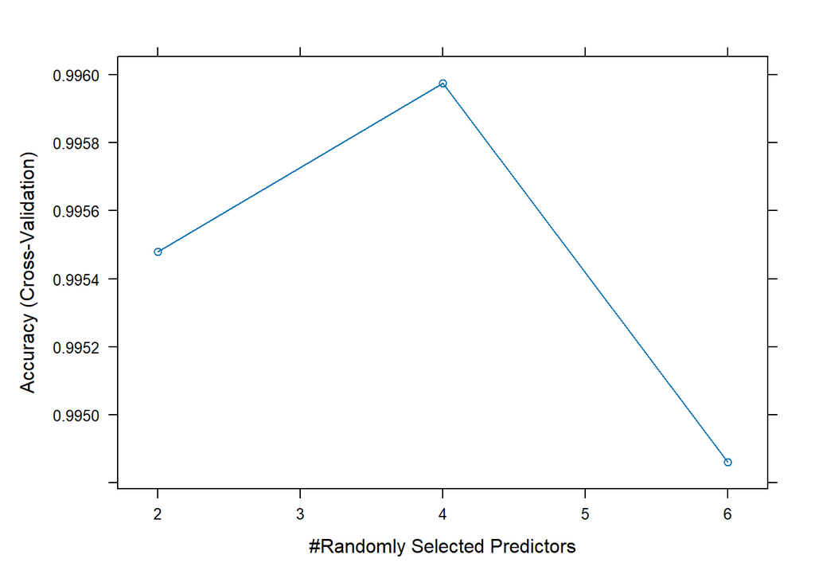

```r
plot(rf_model_tune, type="b")
```

# Precision, Recall and F1 Score for RF with Tune

```r
# Extract Precision, Recall, and F1 Score

precision_rftune <- conf_matrix_rftune$byClass[, "Pos Pred Value"]
recall_rftune <- conf_matrix_rftune$byClass[, "Sensitivity"]
f1_score_rftune <- 2 * ((precision_rftune * recall_rftune) / (precision_rftune + recall_rftune))
support_rftune <- table(Test_data2$active_power_class)

# Combine into a data frame
metrics_rf_tune <- data.frame(
  Class = rownames(conf_matrix_rftune$byClass),
  Precision = precision_rftune,
  Recall = recall_rftune,
  F1_Score = f1_score_rftune
)

# Print the metrics
print(metrics_rf_tune)
```

```
##                                 Class Precision    Recall  F1_Score
## Class: Low                 Class: Low 0.9971537 0.9990494 0.9981007
## Class: Medium-Low   Class: Medium-Low 0.9948718 0.9938525 0.9943619
## Class: Medium-High Class: Medium-High 0.9958974 0.9948770 0.9953870
## Class: High               Class: High 0.9990310 0.9990310 0.9990310
```

# Area under curve for Random forest tuned model

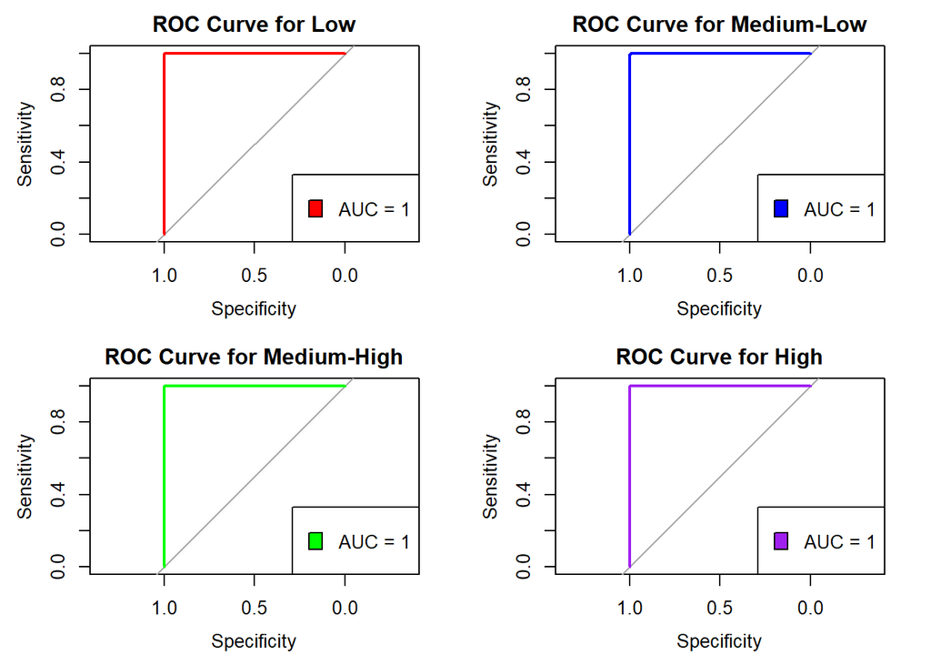

```r
# Predict probabilities on the testing set with the tuned model
rf_prob_tune <- predict(rf_model_tune, newdata = Test_data2, type = "prob")

# Setup plot area
par(mfrow = c(2, 2))  # Adjust grid layout depending on the number of classes, for example 4 classes here
colors <- c("red", "blue", "green", "purple")  # Define colors for each ROC curve


# create List for storing ROC curves
roc_curves_tune <- list()

for (i in 1:ncol(rf_prob_tune)) {
    # Convert multi-class to binary class responses for the current class
    binary_response <- ifelse(Test_data2$active_power_class == colnames(rf_prob_tune)[i], "pos", "neg")

    # Compute ROC curve using the pROC package
    roc_curves_tune[[i]] <- roc(binary_response, rf_prob_tune[, i], levels = c("neg", "pos"))

    # Plot the ROC curve
    plot(roc_curves_tune[[i]], main = paste("ROC Curve for", colnames(rf_prob_tune)[i]), col = colors[i])
    # Add a legend displaying the AUC
    legend("bottomright", legend = c(paste("AUC =", round(auc(roc_curves_tune[[i]]), 3))), fill = colors[i])
}
```

# Standardize the data for numeric columns

```r
# Identify the numeric columns in the dataframe
numeric_columns <- sapply(Energy_New_df_selected2, is.numeric)

# Create a preprocessing object to standardize the numeric data
preProcValues <- preProcess(Energy_New_df_selected2[, numeric_columns], method = c("center", "scale"))

# Apply the preprocessing model to the data
Energy_New_df_selected2[, numeric_columns] <- predict(preProcValues, Energy_New_df_selected2[, numeric_columns])

# Check the summary of the standardized data
summary(Energy_New_df_selected2)
```

```
##  lag_active_power_1 rolling_max_active_power_60 rolling_mean_active_power_30
##  Min.   :-1.5525    Min.   :-1.15893            Min.   :-1.4239
##  1st Qu.:-0.7643    1st Qu.:-0.66243            1st Qu.:-0.6537
##  Median :-0.1516    Median :-0.09677            Median :-0.2525
##  Mean   : 0.0000    Mean   : 0.00000            Mean   : 0.0000
##  3rd Qu.: 0.6101    3rd Qu.: 1.30292            3rd Qu.: 0.6386
##  Max.   : 2.6662    Max.   : 1.54756            Max.   : 2.0910
##  apparent_power       current        rolling_mean_temp_7  power_factor
##  Min.   :-1.6291   Min.   :-1.6190   Min.   :-1.5284     Min.   :-4.8605
##  1st Qu.:-0.7050   1st Qu.:-0.7042   1st Qu.:-0.9185     1st Qu.:-0.9091
##  Median :-0.1454   Median :-0.1438   Median :-0.1898     Median : 0.3329
##  Mean   : 0.0000   Mean   : 0.0000   Mean   : 0.0000     Mean   : 0.0000
##  3rd Qu.: 0.6218   3rd Qu.: 0.6061   3rd Qu.: 0.9317     3rd Qu.: 0.8454
##  Max.   : 2.6257   Max.   : 2.6252   Max.   : 2.0641     Max.   : 1.2523
##  lag_active_power_60 rolling_std_temp_7   active_power_class
##  Min.   :-1.5523     Min.   :-3.6773    Low        :5260
##  1st Qu.:-0.7622     1st Qu.:-0.3547    Medium-Low :4882
##  Median :-0.1508     Median : 0.1219    Medium-High:4882
##  Mean   : 0.0000     Mean   : 0.0000    High       :5161
##  3rd Qu.: 0.6048     3rd Qu.: 0.6088
##  Max.   : 2.6801     Max.   : 1.5352
```

# Spliting standardize data for Svm

```r
set.seed(123)

# Create data partition
Train_partition3 <- createDataPartition(Energy_New_df_selected2$active_power_class, p = 0.8, list = FALSE)

# Train and Test Split
Train_data3 <- Energy_New_df_selected2[Train_partition3, ]
Test_data3 <- Energy_New_df_selected2[-Train_partition3, ]


# Count the total number of observations in the training and test sets
train_count <- nrow(Train_data3)
test_count <- nrow(Test_data3)

# Print the counts
cat("Total number of observations in the training set:", train_count, "\n")
```

```
## Total number of observations in the training set: 16149
```

```r
cat("Total number of observations in the test set:", test_count, "\n")
```

```
## Total number of observations in the test set: 4036
```

# SVM baseline classification model

```r
set.seed(123)
# Train the SVM model

start_time <- Sys.time()

# Train the SVM model using default settings
svm_model <- svm(active_power_class ~ .,
                 data = Train_data3)

end_time <- Sys.time()

# Calculate runtime
runtime <- end_time - start_time
print(paste("Model training runtime:", runtime))
```

```
## [1] "Model training runtime: 1.91388392448425"
```

```r
summary(svm_model)
```

```
##
## Call:
## svm(formula = active_power_class ~ ., data = Train_data3)
##
##
## Parameters:
##    SVM-Type:  C-classification
##  SVM-Kernel:  radial
##        cost:  1
##
## Number of Support Vectors:  677
##
##  ( 120 233 210 114 )
##
##
## Number of Classes:  4
##
## Levels:
##  Low Medium-Low Medium-High High
```

# Make predictions on the test set for svm

```r
pred_svm <- predict(svm_model, Test_data3)

# Evaluate the model
conf_matrix_svm <- table(pred_svm, Test_data3$active_power_class)
print(conf_matrix_svm)
```

```
##
## pred_svm       Low Medium-Low Medium-High High
##   Low         1048          4           0    0
##   Medium-Low     4        970           6    0
##   Medium-High    0          2         969    0
##   High           0          0           1 1032
```

```r
# Calculate accuracy
accuracy <- sum(pred_svm == Test_data3$active_power_class) / length(pred_svm)
print(accuracy)
```

```
## [1] 0.9957879
```

The matrix demonstrates a commendable level of accuracy, with the majority of values aligned along the principal diagonal, signifying a substantial frequency of accurate predictions. A limited number of misclassifications are observed, predominantly occurring between adjacent categories, which implies that the model exhibits some difficulty in distinguishing between closely related classifications. The comparable quantity of instances present in each category within the confusion matrix indicates a relatively equitable dataset.

# Svm model with 5-fold cross validation

```r
set.seed(123)
# Train the SVM model using cross-validation

start_time <- Sys.time()

svm_model_cv <- train(
  active_power_class ~ .,
  data = Train_data3,
  method = "svmRadial",
  trControl = ctrl
)

end_time <- Sys.time()

# Calculate runtime
runtime <- end_time - start_time
print(paste("Model training runtime:", runtime))
```

```
## [1] "Model training runtime: 47.1784219741821"
```

```r
# Print the summary of the SVM model
print(svm_model_cv)
```

```
## Support Vector Machines with Radial Basis Function Kernel
##
## 16149 samples
##     9 predictor
##     4 classes: 'Low', 'Medium-Low', 'Medium-High', 'High'
##
## No pre-processing
## Resampling: Cross-Validated (5 fold)
## Summary of sample sizes: 12919, 12919, 12918, 12920, 12920
## Resampling results across tuning parameters:
##
##   C     Accuracy   Kappa
##   0.25  0.9924454  0.9899232
##   0.50  0.9939316  0.9919057
##   1.00  0.9943651  0.9924838
##
## Tuning parameter 'sigma' was held constant at a value of 0.2752638
## Accuracy was used to select the optimal model using the largest value.
## The final values used for the model were sigma = 0.2752638 and C = 1.
```

```r
# Make predictions on the test set
pred_svm_cv <- predict(svm_model_cv, Test_data3)

# Evaluate the model
conf_matrix_cv <- table(pred_svm_cv, Test_data3$active_power_class)
print(conf_matrix_cv)
```

```
##
## pred_svm_cv    Low Medium-Low Medium-High High
##   Low         1049          4           0    0
##   Medium-Low     2        968           4    0
##   Medium-High    0          4         969    1
##   High           1          0           3 1031
```

```r
accuracy_svm_cv <- sum(pred_svm_cv == Test_data3$active_power_class) / length(pred_svm_cv)
print(accuracy_svm_cv)
```

```
## [1] 0.9952924
```

# Setting up the grid of hyperparameters

```r
set.seed(123
         )
#tune_grid <- expand.grid(
#  sigma = c(0.01, 0.05, 0.1),
 # C = c(0.1, 1, 10)
#)

tune_grid <- expand.grid(
  sigma = c(0.01, 0.05, 0.1, 0.5, 1),
  C = c(0.1, 1, 10, 15, 20)
)

ctrl_svm_tune <- trainControl(
  method = "cv",
  number = 5,
  savePredictions = "final",
  classProbs = TRUE,
  summaryFunction = multiClassSummary
)

# Ensure the target variable is a factor
Train_data3$active_power_class <- as.factor(Train_data3$active_power_class)
Test_data3$active_power_class <- as.factor(Test_data3$active_power_class)

# Rename the levels of the target variable to valid R variable names
levels(Train_data3$active_power_class) <- make.names(levels(Train_data3$active_power_class))
levels(Test_data3$active_power_class) <- make.names(levels(Test_data3$active_power_class))

# Double-check the levels
print(levels(Train_data3$active_power_class))
```

```
## [1] "Low"         "Medium.Low"  "Medium.High" "High"
```

```r
print(levels(Test_data3$active_power_class))
```

```
## [1] "Low"         "Medium.Low"  "Medium.High" "High"
```

# SVM model with hyperparameters

```r
start_time <- Sys.time()

svm_model_tune <- train(active_power_class ~ .,
                        data = Train_data3,
                        method = "svmRadial",
                        probability = TRUE,
                        trControl = ctrl_svm_tune,
                        tuneGrid = tune_grid,
                        metric = "Accuracy")

end_time <- Sys.time()

# Calculate runtime
runtime <- end_time - start_time
print(paste("Model training runtime:", runtime))
```

```
## [1] "Model training runtime: 30.2646102309227"
```

```r
# Print the best model and its parameters
print(svm_model_tune$bestTune)
```

```
##    sigma  C
## 15   0.1 20
```

```r
print(svm_model_tune)
```

```
## Support Vector Machines with Radial Basis Function Kernel
##
## 16149 samples
##     9 predictor
##     4 classes: 'Low', 'Medium.Low', 'Medium.High', 'High'
##
## No pre-processing
## Resampling: Cross-Validated (5 fold)
## Summary of sample sizes: 12919, 12919, 12918, 12920, 12920
## Resampling results across tuning parameters:
##
##   sigma  C     logLoss     AUC        prAUC      Accuracy   Kappa
##   0.01    0.1  0.10322730  0.9978412  0.9918780  0.9767787  0.9690258
##   0.01    1.0  0.07634322  0.9992319  0.9963098  0.9863770  0.9818291
##   0.01   10.0  0.09995918  0.9996515  0.9976942  0.9938076  0.9917404
##   0.01   15.0  0.09700990  0.9996633  0.9976967  0.9947365  0.9929793
##   0.01   20.0  0.09839207  0.9996793  0.9977464  0.9951081  0.9934750
##   0.05    0.1  0.09408667  0.9988012  0.9946522  0.9860674  0.9814158
##   0.05    1.0  0.04788634  0.9998537  0.9982088  0.9943031  0.9924013
##   0.05   10.0  0.05178150  0.9998687  0.9983067  0.9962226  0.9949616
##   0.05   15.0  0.05242162  0.9998468  0.9982245  0.9964703  0.9952920
##   0.05   20.0  0.05030183  0.9998526  0.9982335  0.9967180  0.9956223
##   0.10    0.1  0.11161406  0.9991170  0.9958674  0.9894112  0.9858762
##   0.10    1.0  0.04016777  0.9998633  0.9981665  0.9954796  0.9939705
##   0.10   10.0  0.03768091  0.9998561  0.9981464  0.9965322  0.9953746
##   0.10   15.0  0.03860434  0.9998598  0.9981214  0.9967800  0.9957051
##   0.10   20.0  0.03774525  0.9998583  0.9980836  0.9969658  0.9959528
##   0.50    0.1  0.27014543  0.9984829  0.9926717  0.9904639  0.9872806
##   0.50    1.0  0.25722318  0.9989203  0.9950077  0.9938698  0.9918233
##   0.50   10.0  0.25991416  0.9988272  0.9945618  0.9949843  0.9933098
##   0.50   15.0  0.26111216  0.9988533  0.9947796  0.9947366  0.9929794
##   0.50   20.0  0.27222370  0.9988188  0.9946490  0.9947985  0.9930620
##   1.00    0.1  0.30221508  0.9981132  0.9890917  0.9903401  0.9871158
##   1.00    1.0  0.26931768  0.9986936  0.9942859  0.9932504  0.9909972
##   1.00   10.0  0.26375028  0.9986100  0.9938618  0.9934982  0.9913277
##   1.00   15.0  0.26467229  0.9985842  0.9938535  0.9936221  0.9914929
##   1.00   20.0  0.25077691  0.9986377  0.9937908  0.9934982  0.9913277
##   Mean_F1    Mean_Sensitivity  Mean_Specificity  Mean_Pos_Pred_Value
##   0.9764510  0.9764171         0.9922854         0.9765799
##   0.9861889  0.9861737         0.9954753         0.9862406
```

[output cut: 63 more lines]

```
##   0.9978347
##   0.9979523
##   0.9935966
##   0.9958698
##   0.9966228
##   0.9964513
##   0.9964984
##   0.9935395
##   0.9954600
##   0.9956228
##   0.9957107
##   0.9956276
##
## Accuracy was used to select the optimal model using the largest value.
## The final values used for the model were sigma = 0.1 and C = 20.
```

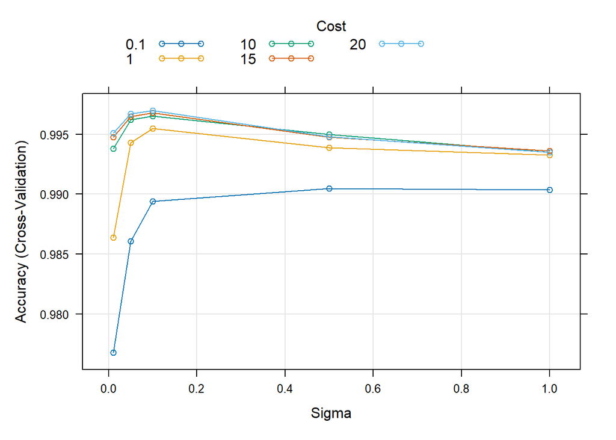

```r
plot(svm_model_tune)
```

```r
# Make predictions on the test set
pred_svm_tune <- predict(svm_model_tune, Test_data3)

# Evaluate the model
conf_matrix_svm_tune <- table(pred_svm_tune, Test_data3$active_power_class)
print(conf_matrix_svm_tune)
```

```
##
## pred_svm_tune  Low Medium.Low Medium.High High
##   Low         1048          1           0    0
##   Medium.Low     4        974           7    0
##   Medium.High    0          1         967    0
##   High           0          0           2 1032
```

```r
 accuracy_svm_tune <- sum(pred_svm_tune == Test_data3$active_power_class) / length(pred_svm_tune)
 print(accuracy_svm_tune)
```

```
## [1] 0.9962834
```

```r
summary(Test_data3)
```

```
##  lag_active_power_1 rolling_max_active_power_60 rolling_mean_active_power_30
##  Min.   :-1.54983   Min.   :-1.158931           Min.   :-1.423863
##  1st Qu.:-0.76566   1st Qu.:-0.662431           1st Qu.:-0.669916
##  Median :-0.15122   Median :-0.095741           Median :-0.212230
##  Mean   :-0.00696   Mean   : 0.003442           Mean   : 0.003616
##  3rd Qu.: 0.61095   3rd Qu.: 1.302922           3rd Qu.: 0.709923
##  Max.   : 2.66419   Max.   : 1.547559           Max.   : 2.087004
##  apparent_power         current          rolling_mean_temp_7  power_factor
##  Min.   :-1.628131   Min.   :-1.610792   Min.   :-1.5284     Min.   :-2.52345
##  1st Qu.:-0.705572   1st Qu.:-0.704248   1st Qu.:-0.9097     1st Qu.:-0.81118
##  Median :-0.139451   Median :-0.135597   Median :-0.1730     Median : 0.34890
##  Mean   : 0.006707   Mean   : 0.006116   Mean   : 0.0036     Mean   : 0.02681
##  3rd Qu.: 0.625814   3rd Qu.: 0.614362   3rd Qu.: 0.9345     3rd Qu.: 0.85739
##  Max.   : 2.618980   Max.   : 2.617001   Max.   : 2.0632     Max.   : 1.23797
##  lag_active_power_60 rolling_std_temp_7    active_power_class
##  Min.   :-1.552300   Min.   :-3.677282   Low        :1052
##  1st Qu.:-0.764235   1st Qu.:-0.334786   Medium.Low : 976
##  Median :-0.150116   Median : 0.145081   Medium.High: 976
##  Mean   : 0.004345   Mean   : 0.004435   High       :1032
##  3rd Qu.: 0.608405   3rd Qu.: 0.611719
##  Max.   : 2.675498   Max.   : 1.535247
```

```r
postResample(pred_svm_tune, Test_data3$active_power_class)
```

```
##  Accuracy     Kappa
## 0.9962834 0.9950428
```